# Test of forecasting models

##### Model testing

###### Weekly data

[figure not shown]

| .model | .type | ME | RMSE | MAE | MPE | MAPE | MASE | RMSSE |
| --- | --- | --- | --- | --- | --- | --- | --- | --- |
| ARIMA(quantity) | Test | 0.2857800 | 0.46890 | 0.28578 | 19.2700 | 19.270 | 0.39684 | 0.40856 |
| ETS(quantity ~ season(method = “N”)) | Test | 0.2930300 | 0.47409 | 0.29303 | 19.9170 | 19.917 | 0.40691 | 0.41308 |
| FASSTER(quantity ~ trend(1)) | Test | -0.1147500 | 0.38994 | 0.35428 | -17.4630 | 29.439 | 0.49195 | 0.33977 |
| prophet(quantity) | Test | -0.0042405 | 0.41544 | 0.30066 | -7.8345 | 22.656 | 0.41750 | 0.36198 |
| SNAIVE(quantity) | Test | 0.3333300 | 0.81650 | 0.66667 | 25.0000 | 58.333 | 0.92573 | 0.71143 |

###### Daily data

[figure not shown]

| .model | .type | ME | RMSE | MAE | MPE | MAPE | MASE | RMSSE |
| --- | --- | --- | --- | --- | --- | --- | --- | --- |
| ARIMA(quantity) | Test | 0.181280 | 0.34152 | 0.18128 | Inf | Inf | 1.3962 | 0.84428 |
| ETS(quantity ~ season(method = “A”)) | Test | -0.042226 | 0.28420 | 0.18607 | -Inf | Inf | 1.4331 | 0.70258 |
| FASSTER(quantity ~ trend(1) + fourier(7)) | Test | -0.081532 | 0.29093 | 0.22693 | -Inf | Inf | 1.7478 | 0.71922 |
| prophet(quantity ~ season(7)) | Test | -0.053686 | 0.28469 | 0.20461 | -Inf | Inf | 1.5759 | 0.70378 |
| SNAIVE(quantity ~ lag(“week”)) | Test | -0.047619 | 0.43644 | 0.19048 | -Inf | Inf | 1.4671 | 1.07890 |

##### Cross validation

Cross validated accuracy for a variety of models using weekly data.

| .model | .type | ME | RMSE | MAE | MPE | MAPE | MASE | RMSSE | ACF1 |
| --- | --- | --- | --- | --- | --- | --- | --- | --- | --- |
| ARIMA(quantity) | Test | -0.0075191 | 1.084065 | 0.7801328 | -Inf | Inf | 1.083293 | 0.9445728 | -0.0314451 |
| ETS(quantity ~ season(method = “N”)) | Test | 0.0083423 | 1.077461 | 0.7662528 | -Inf | Inf | 1.064019 | 0.9388187 | -0.0501597 |
| FASSTER(quantity ~ trend(1)) | Test | -0.0477061 | 1.151219 | 0.8402641 | -Inf | Inf | 1.166792 | 1.0030854 | 0.0617464 |
| prophet(quantity) | Test | -0.1196568 | 1.091095 | 0.8348666 | -Inf | Inf | 1.159297 | 0.9506983 | -0.0348241 |
| SNAIVE(quantity) | Test | -0.0833333 | 1.443376 | 1.0416667 | -Inf | Inf | 1.446459 | 1.2576489 | -0.0527453 |

###### Cross validation- daily

Cross validated accuracy for a variety of models using daily data.

| .model | .type | ME | RMSE | MAE | MPE | MAPE | MASE | RMSSE | ACF1 |
| --- | --- | --- | --- | --- | --- | --- | --- | --- | --- |
| ARIMA(quantity) | Test | 0.1719968 | 0.4660033 | 0.1752919 | NaN | Inf | 1.402975 | 1.180036 | 0.0022768 |
| ETS(quantity ~ season(method = “A”)) | Test | 0.0523478 | 0.4336203 | 0.2286735 | NaN | Inf | 1.830222 | 1.098034 | -0.0152852 |
| FASSTER(quantity ~ trend(1) + fourier(7)) | Test | 0.0782281 | 0.4285844 | 0.2167827 | -Inf | Inf | 1.735053 | 1.085282 | -0.0204113 |
| prophet(quantity ~ season(7)) | Test | 0.0384269 | 0.4239879 | 0.2461915 | -Inf | Inf | 1.970430 | 1.073643 | -0.0208728 |
| SNAIVE(quantity ~ lag(“week”)) | Test | 0.0238095 | 0.5976143 | 0.3095238 | -Inf | Inf | 2.477320 | 1.513308 | -0.0668105 |

#### Site B

##### Seasonality

###### Week

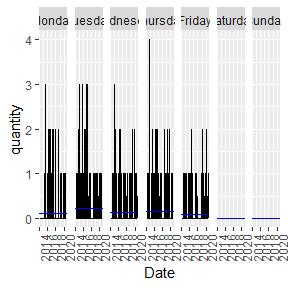

###### Year

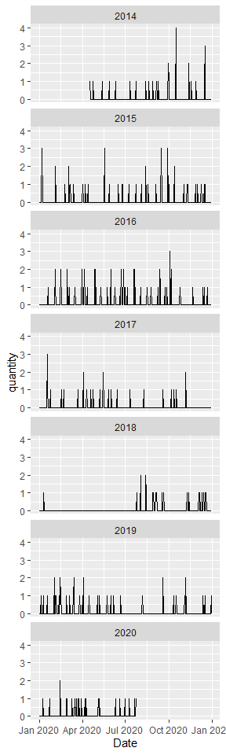

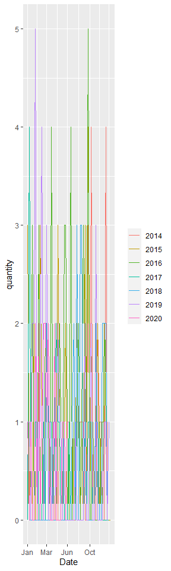

###### Raw data

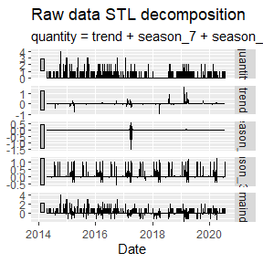

###### Detail of data

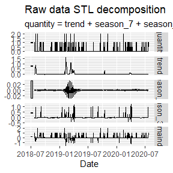

###### Weekly totals

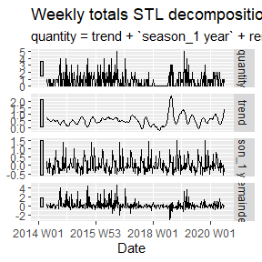

###### Detail of weekly totals

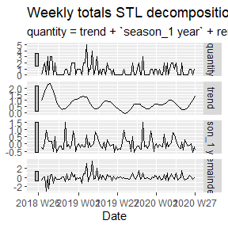

##### Residuals of STL model- raw data and weekly totals

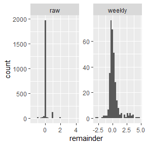

##### Simple exponential smoothing

| .model | term | estimate |
| --- | --- | --- |
| ETS(quantity ~ season(method = “N”)) | alpha | 0.0510261 |
| ETS(quantity ~ season(method = “N”)) | l[0] | 0.6459055 |

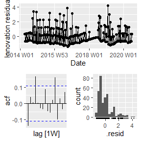

Ljung Box test for autocorrelation of residuals

| .model | lb_stat | lb_pvalue |
| --- | --- | --- |
| ETS(quantity ~ season(method = “N”)) | 35.51043 | 0.0001021 |

##### ARIMA

| .model | term | estimate | std.error | statistic | p.value |
| --- | --- | --- | --- | --- | --- |
| ARIMA(quantity) | ar1 | 0.9018731 | 0.0750963 | 12.0095569 | 0.0000000 |
| ARIMA(quantity) | ma1 | -1.0107219 | 0.0869925 | -11.6185003 | 0.0000000 |
| ARIMA(quantity) | ma2 | 0.1885294 | 0.0618024 | 3.0505200 | 0.0024719 |
| ARIMA(quantity) | sar1 | 0.0611403 | 2.1419619 | 0.0285441 | 0.9772457 |
| ARIMA(quantity) | sar2 | -0.0285571 | 0.1131540 | -0.2523738 | 0.8009112 |
| ARIMA(quantity) | sma1 | -0.0188779 | 2.1435048 | -0.0088070 | 0.9929785 |
| ARIMA(quantity) | constant | 0.0689545 | 0.0095256 | 7.2388623 | 0.0000000 |

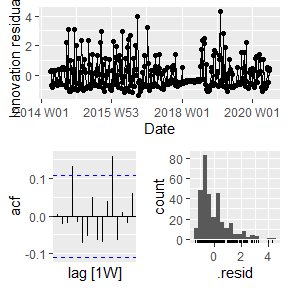

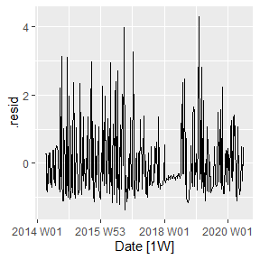

Ljung Box test for autocorrelation of residuals

| .model | lb_stat | lb_pvalue |
| --- | --- | --- |
| ARIMA(quantity) | 24.68882 | 0.0059676 |

##### Model testing

###### Weekly data

[figure not shown]

| .model | .type | ME | RMSE | MAE | MPE | MAPE | MASE | RMSSE |
| --- | --- | --- | --- | --- | --- | --- | --- | --- |
| ARIMA(quantity) | Test | 0.049325 | 0.51020 | 0.49213 | -Inf | Inf | 0.49959 | 0.35046 |
| ETS(quantity ~ season(method = “N”)) | Test | -0.018531 | 0.47177 | 0.43827 | -Inf | Inf | 0.44491 | 0.32406 |
| FASSTER(quantity ~ trend(1)) | Test | 0.507720 | 0.69282 | 0.61368 | -Inf | Inf | 0.62298 | 0.47590 |
| prophet(quantity) | Test | 0.293780 | 0.57359 | 0.55953 | -Inf | Inf | 0.56801 | 0.39400 |
| SNAIVE(quantity) | Test | 0.333330 | 0.81650 | 0.66667 | -Inf | Inf | 0.67677 | 0.56085 |

###### Daily data

[figure not shown]

| .model | .type | ME | RMSE | MAE | MPE | MAPE | MASE | RMSSE |
| --- | --- | --- | --- | --- | --- | --- | --- | --- |
| ARIMA(quantity) | Test | 0.0141270 | 0.32413 | 0.19897 | -Inf | Inf | 1.04670 | 0.60463 |
| ETS(quantity ~ season(method = “A”)) | Test | 0.0241040 | 0.31001 | 0.18325 | NaN | Inf | 0.96402 | 0.57830 |
| FASSTER(quantity ~ trend(1) + fourier(7)) | Test | -0.0630860 | 0.31443 | 0.24194 | -Inf | Inf | 1.27270 | 0.58655 |
| prophet(quantity ~ season(7)) | Test | 0.0074517 | 0.30795 | 0.18820 | NaN | Inf | 0.99003 | 0.57445 |
| SNAIVE(quantity ~ lag(“week”)) | Test | -0.0238100 | 0.51177 | 0.26190 | -Inf | Inf | 1.37780 | 0.95466 |

##### Cross validation

Cross validated accuracy for a variety of models using weekly data.

| .model | .type | ME | RMSE | MAE | MPE | MAPE | MASE | RMSSE | ACF1 |
| --- | --- | --- | --- | --- | --- | --- | --- | --- | --- |
| ARIMA(quantity) | Test | -0.0924687 | 1.029245 | 0.8001085 | -Inf | Inf | 0.8122313 | 0.7069878 | 0.0072847 |
| ETS(quantity ~ season(method = “N”)) | Test | -0.1648498 | 1.146186 | 0.9063780 | -Inf | Inf | 0.9201110 | 0.7873147 | 0.1682406 |
| FASSTER(quantity ~ trend(1)) | Test | -0.0580629 | 1.186955 | 0.8890300 | -Inf | Inf | 0.9025001 | 0.8153190 | 0.2119620 |
| prophet(quantity) | Test | 0.0968921 | 1.085579 | 0.7857842 | -Inf | Inf | 0.7976900 | 0.7456840 | 0.0582826 |
| SNAIVE(quantity) | Test | 0.0000000 | 1.457738 | 1.0000000 | -Inf | Inf | 1.0151515 | 1.0013196 | 0.2843137 |

###### Cross validation- daily

Cross validated accuracy for a variety of models using daily data.

| .model | .type | ME | RMSE | MAE | MPE | MAPE | MASE | RMSSE | ACF1 |
| --- | --- | --- | --- | --- | --- | --- | --- | --- | --- |
| ARIMA(quantity) | Test | -0.0582267 | 0.2207598 | 0.1433771 | -Inf | Inf | 0.7468548 | 0.4089675 | -0.0512831 |
| ETS(quantity ~ season(method = “A”)) | Test | -0.0648977 | 0.2180195 | 0.1415660 | NaN | Inf | 0.7374211 | 0.4038910 | -0.0306467 |
| FASSTER(quantity ~ trend(1) + fourier(7)) | Test | 0.0639730 | 0.2168716 | 0.1039410 | NaN | Inf | 0.5414313 | 0.4017645 | -0.0294029 |
| prophet(quantity ~ season(7)) | Test | -0.0719413 | 0.2192882 | 0.1471370 | NaN | Inf | 0.7664402 | 0.4062415 | -0.0155125 |
| SNAIVE(quantity ~ lag(“week”)) | Test | 0.0476190 | 0.2182179 | 0.0476190 | 100 | 100 | 0.2480489 | 0.4042586 | -0.0511905 |

#### Site C

##### Seasonality

###### Week

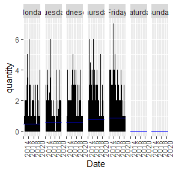

###### Year

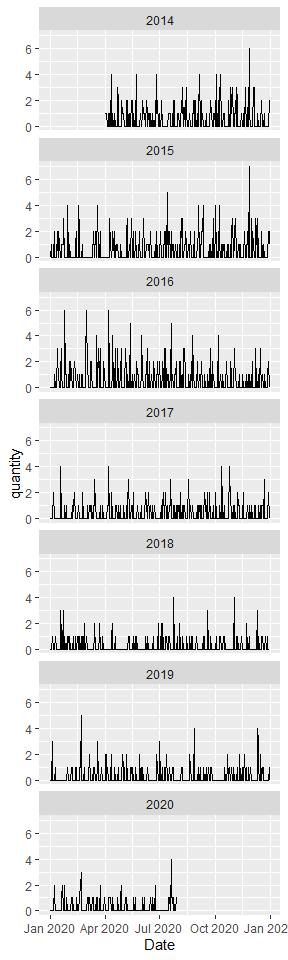

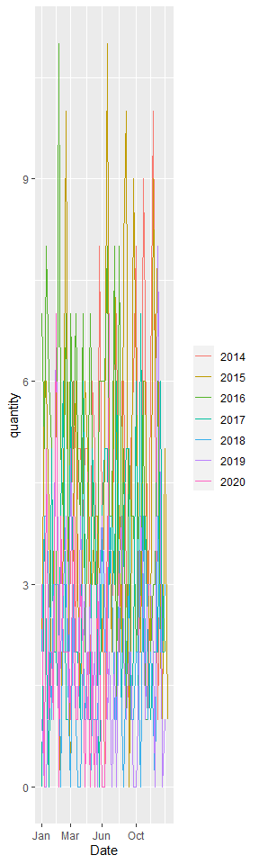

###### Raw data

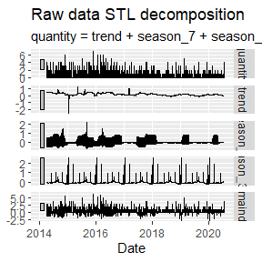

###### Detail of data

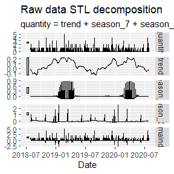

###### Weekly totals

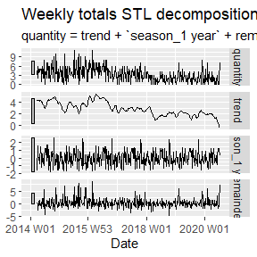

###### Detail of weekly totals

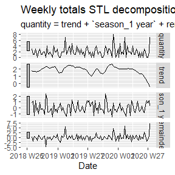

##### Residuals of STL model- raw data and weekly totals

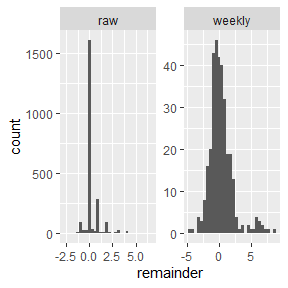

##### Simple exponential smoothing

| .model | term | estimate |
| --- | --- | --- |
| ETS(quantity ~ season(method = “N”)) | alpha | 0.0550134 |
| ETS(quantity ~ season(method = “N”)) | l[0] | 4.2467197 |

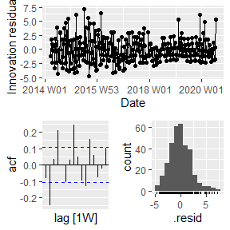

Ljung Box test for autocorrelation of residuals

| .model | lb_stat | lb_pvalue |
| --- | --- | --- |
| ETS(quantity ~ season(method = “N”)) | 87.48554 | 0 |

##### ARIMA

| .model | term | estimate | std.error | statistic | p.value |
| --- | --- | --- | --- | --- | --- |
| ARIMA(quantity) | ar1 | -0.9658588 | 0.0355692 | -27.1543853 | 0.0000000 |
| ARIMA(quantity) | ma1 | 0.0059256 | 0.0441196 | 0.1343079 | 0.8932412 |
| ARIMA(quantity) | ma2 | -0.8966608 | 0.0426436 | -21.0268689 | 0.0000000 |
| ARIMA(quantity) | sar1 | 0.0653839 | 0.0596098 | 1.0968645 | 0.2735028 |
| ARIMA(quantity) | sar2 | 0.1455756 | 0.0702639 | 2.0718414 | 0.0390591 |
| ARIMA(quantity) | constant | -0.0100556 | 0.0123544 | -0.8139306 | 0.4162734 |

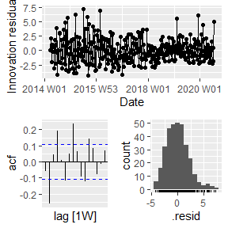

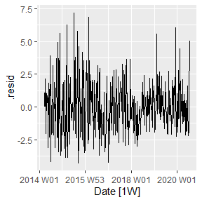

Ljung Box test for autocorrelation of residuals

| .model | lb_stat | lb_pvalue |
| --- | --- | --- |
| ARIMA(quantity) | 83.59398 | 0 |